# The global spread of crop pests and pathogens - Bebber - 2014 - Global Ecology and Biogeography - Wiley Online Library

[Global Ecology and Biogeography](https://onlinelibrary.wiley.com/journal/14668238)

[Volume 23, Issue 12](https://onlinelibrary.wiley.com/toc/14668238/2014/23/12) p. 1398-1407

[figure not shown]

Research Paper

Open Access

# The global spread of crop pests and pathogens

[Daniel P. Bebber](https://onlinelibrary.wiley.com/action/doSearch?ContribAuthorRaw=Bebber%2C+Daniel+P),

[Timothy Holmes](https://onlinelibrary.wiley.com/action/doSearch?ContribAuthorRaw=Holmes%2C+Timothy),

[Sarah J. Gurr](https://onlinelibrary.wiley.com/action/doSearch?ContribAuthorRaw=Gurr%2C+Sarah+J),

First published: 27 August 2014

https://doi.org/10.1111/geb.12214

Citations: 234

Editor: Peter van Bodegom

## Abstract

### Aim

To describe the patterns and trends in the spread of crop pests and pathogens around the world, and determine the socioeconomic, environmental and biological factors underlying the rate and degree of redistribution of crop-destroying organisms.

### Location

Global.

### Methods

Current country- and state-level distributions of 1901 pests and pathogens and historical observation dates for 424 species were compared with potential distributions based upon distributions of host crops. The degree of ‘saturation’, i.e. the fraction of the potential distribution occupied, was related to pest type, host range, crop production, climate and socioeconomic variables using linear models.

### Main conclusions

Despite ongoing dispersal of crop pests and pathogens, the degree of biotic homogenization of the globe remains moderate and regionally constrained, but is growing. Fungal pathogens lead the global invasion of agriculture, despite their more restricted host range. Climate change is likely to influence future distributions. Improved surveillance would reveal greater levels of invasion, particularly in developing countries.

## Introduction

The global redistribution of species by, and in response to, human activities is one of the defining features of the Holocene (Baiser *et al*., 2012). This process of biotic homogenization has led to the displacement of local specialist species by global generalists, to the detriment of biodiversity (McKinney & Lockwood, 1999). Whether through deliberate or accidental introduction, many natural environments now host assemblages of exotic species that threaten populations of native species (McGeoch *et al*., 2010) and alter ecosystem function (Clavel *et al*., 2010). Though the impacts of invasive alien species are variable and not necessarily negative (Davis *et al*., 2011), the arrival of invasive pests and pathogens of crops or forest species is unequivocally negative from the standpoint of food security and landscape resilience.

Crop pests and diseases have plagued farmers since the dawn of agriculture (Stukenbrock & McDonald, 2008). Their menace to global food security persists (Flood, 2010). In contrast to their wild relatives, field crops have been artificially selected and bred predominantly for increased yield and, to a lesser extent, for disease resistance, and are thus easy prey for natural enemies that have tracked them from the wild to the farm (Rosenthal & Dirzo, 1997; Lindig-Cisneros *et al*., 2002). Short productive ‘honeymoons’ have resulted as crops spread into pest-free regions, but, eventually, their pursuers have caught up (Dark & Gent, 2001). Analogously, non-pest exotic invasive species may benefit from the absence of specialist natural enemies when introduced to virgin habitats (Mitchell & Power, 2003). This global game of cat-and-mouse continues, as, for example, in the case of the rubber tree (*Hevea brasiliensis*), which is no longer grown commercially in its region of origin because of the indigenous fungal pathogen South American leaf blight (*Microcyclis ulei*) (Lieberei, 2007); by the repeated devastations of banana by new pathotypes of fusarium wilt fungus (*Fusarium oxysporum* f. sp. *cubense*) (Ploetz & Churchill, 2011) and by the rapid spread of the virulent Ug99 strain of wheat stem rust fungus (*Puccinia graminis* f. sp. *tritici*) through Africa and the Middle East (Singh *et al*., 2011).

Analysis of the spread of crop pests and pathogens must consider where pests are currently found, where they could occur and how they are spreading. Data on pest occurrence have been used to demonstrate the roles of environmental and socioeconomic variables in determining known occurrences and potential biases in knowledge (Bebber *et al*., 2014), echoing results for invasive species in general (Pyšek *et al*., 2010). Occurrence data are also used in species distribution models (SDM) to forecast potential distributions by estimating climatic and environmental tolerances from current distributions and thence extrapolating from these (Elith & Leathwick, 2009). SDMs have been used to generate potential distributions of a number of crop pests and pathogens, and how these might change in future (Baker *et al*., 2000; Hill *et al*., 2012). A related approach is to use co-occurring pests as indicators of environmental suitability, and to predict the potential for establishment from observed pest assemblages in a given region (Worner & Gevrey, 2006; Paini *et al*., 2010). Observed changes in the distributions of pests and pathogens have been studied in relation to drivers such as trade, transport, natural dispersal and climate change (Brown & Hovmøller, 2002; Anderson *et al*., 2004; Bebber *et al*., 2013; Bacon *et al*., 2014). Likely trajectories of future spread can be estimated by invoking various population dynamics and diffusion models (Robinet *et al*., 2012).

A fundamental assumption in these approaches is that pests and pathogens, as with other invasive species, are not found in all areas suitable for them (Václavík & Meentemeyer, 2009). International phytosanitary measures undertaken by governments and organizations such as European Plant Protection Organization (EPPO) and its North American equivalent (NAPPO) that seek to limit the spread of crop pests (and other invasive species), are predicated on the assumption of ongoing dispersal (Miller *et al*., 2009). Despite the best efforts of the plant protection agencies and customs officers, however, trade and natural dispersal eventually allow pests to reach their hosts (Anderson *et al*., 2004), with potentially devastating consequences (Fisher *et al*., 2012). Reports of new pest introductions are rising (Huang *et al*., 2011; Fisher *et al*., 2012; Bebber *et al*., 2013), prompting the following questions: how far has the saturation of global agriculture by pests proceeded; what endogenous (e.g. host range) and exogenous (e.g. climate) factors determine the degree of spread; and when, in the absence of changes in crop distributions, will the known complement of crop pests finally reach all suitable countries and crops?

Here we address these question using global databases of pest (*sensu stricto*, i.e. arthropods, gastropods and nematodes), pathogen (fungi, oomycetes, protozoa, bacteria and viruses) and crop distributions, host ranges and observations of pest spread. We use the acronym CPP (crop pests and pathogens) hereafter to capture crop-destroying organisms. We investigate the factors that influence the number of countries reached by pests, and the number of pests in each country. We show that despite extensive mixing, pest assemblages remain regionalized and strongly determined by latitude. However, for a subset of pests for which historical observation data are available spread has proceeded at a rate that could saturate many economically important countries with pests by the middle of this century.

## Methods

Current known distributions of 1901 CPPs at national and subnational levels (e.g. US states) were obtained, with permission, from the CABI PlantWise database (CABI, 2013). These data have been abstracted from thousands of sources in the scientific and grey literature, with records dating back more than a century. PlantWise is curated to retain only records for which the presence and correct identification of a pest can be assured with high confidence, and various subsets of the data have been used previously in analyses of CPP occurrence (Worner & Gevrey, 2006; Paini *et al*., 2010; Bacon *et al*., 2014; Bebber *et al*., 2014). A temporal dataset of observations over time of 424 CPPs was abstracted manually from the CABI distribution maps of plant pests and plant diseases published between 2000 and 2011 (Bebber *et al*., 2013). Crop production data for 168 crops were obtained at national levels for the decade 2001–10 from the UN Food and Agriculture Organization (FAO) (FAO, 2013). Mean annual temperature and rainfall, and seasonality of temperature and rainfall (Hijmans *et al*., 2005) were averaged over the crop-growing areas (Portmann *et al*., 2010) of the regions in the study.

Crop categories were converted to genera to match host-specificity databases obtained from CABI. We restricted host range to the generic level, to reduce possible uncertainties and omissions at the specific level. Our host range data should be interpreted as the number of genera in which at least one species is a host, and not that a CPP will attack every species within the genus as a host. Hosts listed as plant families were converted to genera, and these genera then matched to crops in the FAO database. In this way, the production quantity of crops in each country susceptible to each pest could be estimated. Some crop categories in the FAO database contain multiple crop species. For example, a group of spices listed together included anise (*Pimpinella anisum*), badian (*Illicium anisatum*), fennel (*Foeniculum vulgare*) and coriander (*Coriandrum sativum*). In this case, there was no way to determine the relative contribution of each genus to total production for that group, and production was divided equally among the genera. The quantities of these product categories were very small, and it is unlikely that severe bias would be introduced by this methodology. CPPs that attacked only plants not listed as crops (e.g. forest trees, wild species and ornamentals) were excluded, leaving 1796 CPPs, of which 1133 were ‘pests’ (insects and nematodes) and 663 were ‘pathogens’ (fungi, oomycetes, bacteria, viruses, phytoplasmas).

We assumed that a CPP could potentially occur in any country in which its host crop is grown. Host availability has been shown to be important for insect pests in Europe (Bacon *et al*., 2014) and for total pest and pathogen numbers globally (Bebber *et al*., 2014). The degree of saturation for each pest was calculated as the number of countries currently infested divided by the number of countries it could infest, based upon current crop distributions and known host preferences. The degree of saturation for a country was the number of CPPs currently present divided by number that could occur. Potential future changes in crop distributions, climate change or host specialization were not considered.

Ordinations of countries based on the presence of CPPs were conducted using correspondence analysis (CA) (Legendre & Legendre, 1998). Previous studies have used neural network clustering algorithms to group countries by pest assemblage (Worner & Gevrey, 2006; Paini *et al*., 2010), but we preferred to use ordination to acknowledge the likely continuous nature of variation in assemblages among countries. The CPP communities for individual US states and Canadian provinces were extracted from the database, to determine variation in CPP assemblages within these large countries. Only the USA and Canada were analysed in this way, because of the high probability of reliable CPP presence data in these two countries (Bebber *et al*., 2014). Crop production data for individual US states and Canadian provinces were not available from the FAO, so their crop community analyses were conducted on country-level data.

CPP– and crop–community distances were calculated using the square-root transformed Jaccard distance (Legendre & Legendre, 1998), in which only shared presences, but not shared absences, influence distance between sites. Using only shared presences prevents the ‘double-zero problem’, whereby the distance between sites that do not share any species would be erroneously small, when in fact shared absences do not necessarily indicate ecological similarity of sites (Legendre & Legendre, 1998). The square-root transformation makes the distance metric Euclidean (Legendre & Legendre, 1998). Permutational multivariate analysis of variance (Anderson, 2001) of these distance matrices was conducted using the *adonis* function in the *vegan* package (Oksanen *et al*., 2013) for R version 3.0.1 (R Development Core Team, 2013). Per capita gross domestic product (GDP) and mean total agricultural production (2001–10) were log-transformed prior to analysis, as this has been found to linearize relationships with pest numbers per country (Bebber *et al*., 2014). Mantel tests were used to correlate CCP– and crop–community distances.

## Results

The majority of CPPs were either present in countries in which they were expected (15.6% of species-by-country cases), not present in those countries (23.6%) or not present in countries in which they were not expected (60.0%). This left 24 CPPs (1.3%) found in more countries than expected under saturation, that is, 0.8% of all species-by-country cases. These cases were mainly due to CPPs affecting non-host crops. For example, the fungus *Puccinia horiana* was reported in 54 countries, but was only expected to be present in eight countries based on FAO crop production data. This is because the fungus attacks *Chrysanthemum*, a genus only listed by the FAO as the rarely grown natural insecticide producer of ‘pyrethrum’. Ornamental varieties of *Chrysanthemum* are grown more widely, therefore the actual potential distribution was considerably broader than that inferred from FAO crop production data. The white pine blister rust fungus, *Cronartium ribicola*, was found in all 36 countries where its telial spore stage host, *Ribes* spp., is grown as a crop. The distributions of the aecial hosts, pines in subgenus *Strobus*, and of wild *Ribes*, were considerably larger than those of domesticated *Ribes* and therefore the known distribution of *C. ribicola* is likely to be an underestimate.

CPP assemblages were geographically distinct, and five major regions were discernible: Europe and Central Asia; North America; Africa and the Middle East; Asia-Pacific and Australasia; and Latin America and the Caribbean (Fig. 1 & [Fig. S1](http://onlinelibrary.wiley.com/doi/10.1111/geb.12214/suppinfo) in Supporting Information). An exception was New Zealand, which, despite its geographical isolation, shared hundreds of CPPs with the USA, Europe, China and India, as well as with Australia. Climatic factors, absolute latitude, per capita GDP, agricultural production, geography (whether island, coastal or landlocked) and membership of the Commonwealth explained a small but significant fraction of the variance in the composition of CPP assemblages amongst countries (Table 1). Crop assemblages were also related to these variables (Table 2). Distances between CPP assemblages were highly correlated with crop assemblages, when conditioned upon geographical distance (Fig. 2; partial Mantel test, Pearson's *r* = 0.70, *P* = 0.001).

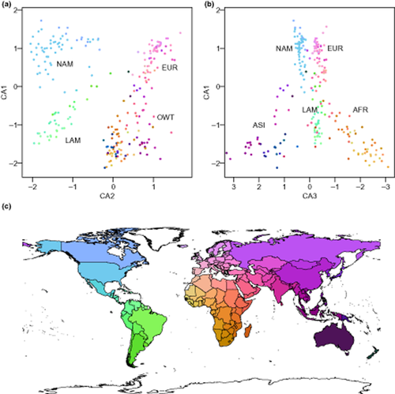

**Figure 1**

Open in figure viewer[PowerPoint](https://onlinelibrary.wiley.com/action/downloadFigures?id=geb12214-fig-0001&doi=10.1111%2Fgeb.12214)

Table 1. Economic and physical factors related to crop pest and pathogen (CPP) assemblages. Model fitted by permutational multivariate ANOVA on square-root transformed Jaccard distances among countries, based on presences of CPPs

[output not shown]

- GDP, gross domestic product; n.a., not applicable. Production is total crop production. Crop diversity is rarefaction species richness of a random sample of 1000 t of crops. Temperature and precipitation SD is the standard deviation of monthly means. Geography refers to whether a country is an island, coastal, or landlocked. Commonwealth is current or historical membership of the Commonwealth. DF, Degrees of Freedom; SS, Sum of Squares; MS, Mean Square.

Table 2. Economic and physical factors related to crop assemblages. Model fitted by permutational multivariate ANOVA on square-root transformed Jaccard distances among countries, based on log-transformed crop production

| Predictor | DF | SS | MS | *F* | *r*<sup>2</sup> (%) | *P* |
| --- | --- | --- | --- | --- | --- | --- |
| Log (per capita GDP) | 1 | 3.63 | 3.63 | 12.7 | 5.1 | 0.001 |
| Log (production) | 1 | 4.23 | 4.23 | 14.8 | 5.9 | 0.001 |
| Crop diversity | 1 | 2.38 | 2.38 | 8.3 | 3.3 | 0.001 |
| Temperature mean | 1 | 3.90 | 3.90 | 13.7 | 5.5 | 0.001 |
| Temperature SD | 1 | 1.24 | 1.24 | 4.3 | 1.7 | 0.001 |
| Precipitation mean | 1 | 0.96 | 0.96 | 3.3 | 1.3 | 0.001 |
| Precipitation SD | 1 | 0.64 | 0.64 | 2.2 | 0.9 | 0.003 |
| Absolute latitude | 1 | 0.75 | 0.75 | 2.6 | 1.1 | 0.001 |
| Geography | 2 | 1.11 | 0.56 | 2.0 | 1.6 | 0.001 |
| Commonwealth | 1 | 0.40 | 0.40 | 1.4 | 0.6 | 0.059 |
| Residuals | 183 | 52.23 | 0.29 | n.a. | 73.1 | n.a. |
| Total | 194 | 71.48 | n.a. | n.a. | 100.0 | n.a. |

- GDP, gross domestic product; n.a., not applicable. Production is total crop production. Crop diversity is rarefaction species richness of a random sample of 1000 t of crops. Temperature and precipitation SD is the standard deviation of monthly means. Geography refers to whether a country is an island, coastal, or landlocked. Commonwealth is current or historical membership of the Commonwealth. DF, Degrees of Freedom; SS, Sum of Squares; MS, Mean Square.

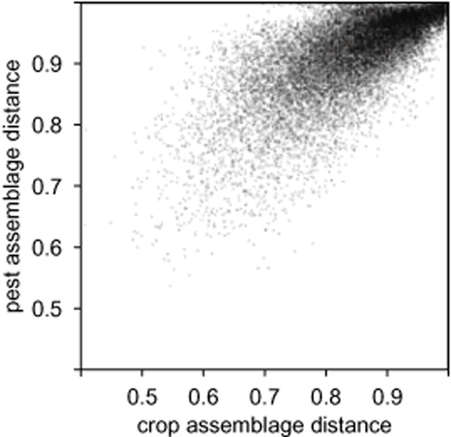

**Figure 2**

Open in figure viewer[PowerPoint](https://onlinelibrary.wiley.com/action/downloadFigures?id=geb12214-fig-0002&doi=10.1111%2Fgeb.12214)

Crop pest and pathogen assemblage distances versus crop assemblage distances. Distances are square-root transformed Jaccard distances. Each point is a pair of countries. Partial Mantel test, Pearson's *r* = 0.70, *P* = 0.001.

Relatively few CPPs were restricted to a single region. Africa had 30 endemic CPPs, Asia 102, Europe 20, North America 28, the Pacific 29, while the Middle East had none. Many of these regional endemics were insects, with 21.5% of Coleoptera, 23.6% of Diptera, 29.4% of Orthoptera and 16.7% of Lepidoptera being regional endemics. The fraction of regionally endemic Hemiptera (12.3%) and Thysanoptera (2.9%) was lower, however. Pathogens had lower endemicity, with 9.5% of bacteria, 5.7% of fungi, 8.5% of Oomycota and 14.8% of viruses being restricted to one region. Fifty-five CPPs were found in only one country (or US state/Canadian province), of which 10 were viruses. India and Australia had the most country-endemic CPPs, with nine each.

Most countries reported about one-fifth of the pests they could theoretically support, if pests occurred in every country known to grow their host crops ([Table S1](http://onlinelibrary.wiley.com/doi/10.1111/geb.12214/suppinfo)). Australia, China, France, India, Italy, the UK and the USA carried more than half of their saturated pest loads. Major agricultural producing nations, and also South American countries, were amongst those able to support the largest numbers of pests ([Table S1](http://onlinelibrary.wiley.com/doi/10.1111/geb.12214/suppinfo)). Country pest saturation has increased approximately linearly since the 1950s, when averaged over all regions, but there was great variability in trajectories amongst individual countries (Fig. 3). Saturation increased linearly in the USA and China, whereas saturation decelerated in India and Great Britain. If late 20th-century saturation rates persist into the future, then the USA, UK, Germany, Italy, France, Japan, India and China would have fully saturated pest distributions by 2050 ([Table S1](http://onlinelibrary.wiley.com/doi/10.1111/geb.12214/suppinfo)).

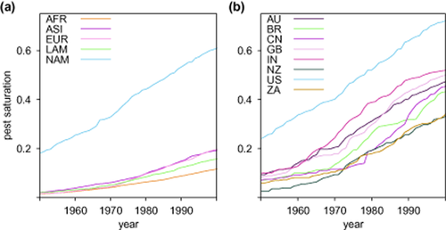

**Figure 3**

Open in figure viewer[PowerPoint](https://onlinelibrary.wiley.com/action/downloadFigures?id=geb12214-fig-0003&doi=10.1111%2Fgeb.12214)

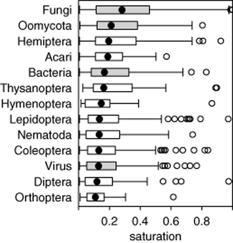

**Figure 4**

Open in figure viewer[PowerPoint](https://onlinelibrary.wiley.com/action/downloadFigures?id=geb12214-fig-0004&doi=10.1111%2Fgeb.12214)

Crop pest and pathogen (CPP) category saturation in 2000. Filled points show the median, boxes show interquartile range, ‘whiskers’ show 1.5 times the interquartile range and open points show extremes. Only categories with > 20 CPPs are shown. ‘Pathogens’ are more saturated than ‘pests’ (*t*-test, 0.073 ± 0.015 greater saturation, *t* = 4.9, d.f. = 1793, *P* = 10<sup>−6</sup>).

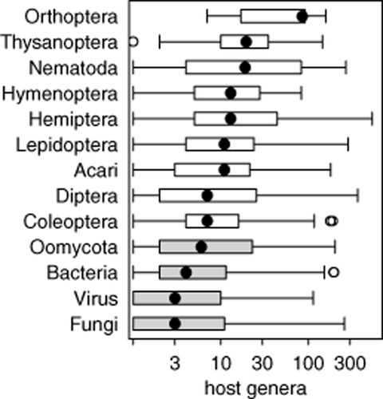

**Figure 5**

Open in figure viewer[PowerPoint](https://onlinelibrary.wiley.com/action/downloadFigures?id=geb12214-fig-0005&doi=10.1111%2Fgeb.12214)

Host range per crop pest and pathogen (CPP) category. Filled points show median host crop genera per CPP, boxes show interquartile range, ‘whiskers’ show 1.5 times the interquartile range and open points show extremes. Only categories with > 20 CPPs are shown.

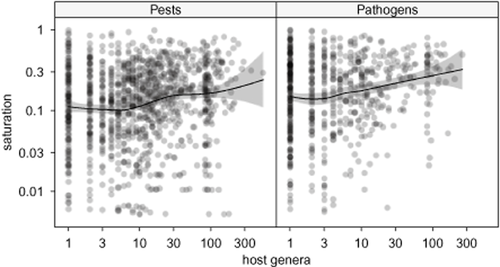

**Figure 6**

Open in figure viewer[PowerPoint](https://onlinelibrary.wiley.com/action/downloadFigures?id=geb12214-fig-0006&doi=10.1111%2Fgeb.12214)

Saturation by host range. Current saturation per pest versus number of host genera per pest, for arthropod and nematode pests, and microbial pathogens. Saturation increases with host diversity. Points show individual species, curves show fitted smooths with 95% confidence limits of the mean. Saturation increased weakly but significantly with host range (linear model, *r*<sup>2</sup> = 0.11, *F*<sub>31,792</sub> = 71.3, *P* < 10<sup>15</sup>), and the effect was greater in pathogens (0.31 ± 0.05 countries per host genus), compared with pests (0.20 ± 0.04 countries per host genus), interquartile range 3–27 versus 1–11 crop genera, Mann–Whitney test, *P* < 10<sup>−6</sup>.

## Discussion

The small but significant influence of climatic variables in determining CPP distributions, whether directly or indirectly through crop distributions, supports the view that climate change is likely to significantly affect pest pressure on agriculture (Bebber *et al*., 2013). The strong dependence of CPP distributions on their hosts suggests that modelling the distribution of the host may afford a better approach than estimating the potential distribution of the pest itself (Sutherst, 2014). Combined bioclimatic modelling of host and pest has shown that soybean distribution could strongly limit the future distribution of the beetle pest *Cerotoma trifurcata* (Berzitis *et al*., 2014). Unlike wild species (Chen *et al*., 2011) and pests (Bebber *et al*., 2013), crops may be less able to track favoured climates to higher latitudes because many plants are entrained to particular photoperiods (Parry *et al*., 1999) or soil types. In addition, crop distributions can change for other, sometimes unpredictable, reasons. Crops can be bred to tolerate novel conditions (Cattivelli *et al*., 2008), while localized climatic variability can unexpectedly boost or devastate harvests (Porter & Semenov, 2005; Iizumi *et al*., 2014). Land-use change and economic forces, such as the use of crops for biofuels (Pimentel *et al*., 2009), have resulted in unexpected shifts in production, indicating that projections of future agricultural scenarios will require detailed modelling. Furthermore, climatic controls over crops and their pests can be decoupled, for instance where an annual crop does not need to overwinter when farmers are able to harvest and store seed, but potential pests and pathogens would be limited by exposure to lethally cold temperatures. Climate change could also lead to phenological mismatching between the life cycles of host and crop where responses differ (Donnelly *et al*., 2011). The degree to which hosts and climate control different CPP distributions requires further analysis.

As with current distributions, analysis of the rates of change in saturation must be interpreted with caution due to delays between the arrival of a CPP in a country, expansion in its population to noticeable levels, identification and reporting (Crooks, 2005; Bebber *et al*., 2013). Deceleration in saturation over time is expected due to variation in the mobility of pests and the availability of suitable crops, such that fast-moving pests will saturate first, leaving slower-moving pests to ‘trickle in’ later. Conversely, increasing international trade could accelerate the saturation rate (Hulme, 2009). Until saturation rates decline further or near completion, estimating the parameters for the saturation curve is likely to be futile due to unforeseeable changes in the dispersal and description process, as has been shown analogously for species discovery curves (Bebber *et al*., 2007).

Variation in the degree of saturation and rates of spread among different CPP groups and species can be difficult to interpret. The greater mean saturation by some microbial pathogens than arthropod pests is surprising, given that host range is generally broader in arthropods than in pathogens. This could be because microbes are more likely to be transported by, persist in and remain undetected in shipments of produce than are arthropods. There is, however, considerable variability among taxonomic groups within these broad categories. While saturation generally increases with host range, fungi are among the most-saturated groups, but simultaneously have among the most restricted host ranges. One of the advantages of host generalization is thought to be increased potential to establish in new environments, at the cost of lower optimal performance (Barrett & Heil, 2012). Other factors, such as airborne dispersal, survival in transport or difficulty in detection during quarantine, might allow pathogens to spread more readily than arthropods and nematodes. The limited distributions of viruses and nematodes (though with notable exceptions) could be explained because these groups are soil-borne (or, for certain viruses, vector-borne), lack the means for autonomous dispersal and are hard to identify without molecular methods (De Waele & Elsen, 2007). In the tropics, infestation by nematodes is often mistaken for abiotic stress (De Waele & Elsen, 2007), and many species are not considered to be invasive simply because their distributions are poorly known (Singh *et al*., 2013). However, beetles (Coleoptera) and flies (Diptera), which are both mobile and relatively easy to identify, also have limited distributions.

The rapid spread of the tropical *Meloidogyne* root knot nematodes may have been facilitated by their wide host range (including many non-crop plants), high fecundity, protective gelatinous matrix in which eggs are laid, microscopic size which makes them difficult to detect in quarantine and because their parthenogenetic reproduction allows establishment with relatively few propagules (Singh *et al*., 2013). These nematodes have been identified as amongst the most serious threats to global agriculture (Jones *et al*., 2013). The fungi *Phoma caricae-papayae* (causing leaf spot of papaya), *Didymella lentis* (teleomorph of *Ascochyta lentis*, attacking lentil *Lens culinaris*) and *Erysiphe cruciferarum* (powdery mildew of brassicas) have also spread rapidly, but in contrast to the root knot nematodes they have a very restricted host range. The production and trade of the sole host of *P. caricae-papayae*, the papaya (*Carica papaya*) has increased in recent years (Evans & Ballen, 2012), which may explain the rapid spread of this disease. However, there does not seem to have been a concurrent growth in the production of lentils or brassicas to explain the trends in *D. lentis* and *E. cruciferarum*. Such post-hoc interpretations of patterns for individual species must be treated with caution, given the large uncertainties in the available observational data, our knowledge of host ranges and the potential for idiosyncratic changes in distributions.

## Acknowledgements

Data available with permission from CABI. D.P.B. is a Senior Research Fellow at Exeter University. S.J.G. gratefully acknowledges BBSRC funding which supported this work.

## References

### Biosketches

**D. P. Bebber** is an ecologist with an interest in the changing distributions of crop pests and pathogens, the influence of climate change on global food security and also the ecology of forests.

**T. Holmes** is a member of the business innovations team at CABI, looking for new and interesting ways to apply technologies to the activities of the organization.

**S. J. Gurr** works on crop diseases (notably of rice and wheat), with particular emphasis on fungal infestations and their global movement and control. She is also interested in fungal biotechnology.

## Citing Literature

[figure not shown]

[Volume23, Issue12](https://onlinelibrary.wiley.com/toc/14668238/2014/23/12)

December 2014

Pages 1398-1407

beta

powered by

[figure not shown]

### Recommended

[figure not shown]

8

196

0

hide